# logRR

Kamau Lindhardt, lbk125

2024-07-06

Sources for developing approaches in meta-analysis:

https://wviechtb.github.io/metafor/reference/rma.mv.html https://www.taylorfrancis.com/chapters/edit/10.1201/9780429061240-8/multivariate-meta-analysis-ding-geng-din-chen-karl-peace https://training.cochrane.org/handbook/current/chapter-06 https://training.cochrane.org/handbook/current/chapter-10

It is not uncommon for studies to have multiple outcome measures which lead to statistical multivariate analysis. The results of studies with multiple outcomes and/or endpoints are typically synthesized via conventional univariate meta-analysis (UMA) on each outcome separately, ignoring the correlations between the outcomes. The impact of ignoring the within-study correlation has been explored extensively in the statistical literature, with issues including overestimated variance of the pooled eﬀect size and biased estimates, which in turn may inﬂuence statistical inferences. In this case, multivariate meta-analysis should be used to synthesize multiple outcomes while taking into account their correlations, often resulting in superior parameter estimation. With study-level moderators or predictors, multivariate meta-regression can also be developed in parallel with multivariate regression techniques.

Formulae to estimate effects (and their standard errors)?

# STEP 0

PREPARING SCRIPT AND READ IN THE DATA ##########################################################################################################################################

```r
# Clean workspace
rm(list = ls())
```

## Loading required packages and libraries

```r
# Suppress warnings to avoid clutter in the console output
suppressWarnings({

  # Load multiple add-on packages using pacman::p_load for efficiency
  pacman::p_load(
    conflicted,       # an Alternative Conflict Resolution Strategy
    here,             # Easy file referencing by using the top-level directory of a file project
    tidyverse,        # Comprehensive collection of R packages for data science
    readxl,           # To read Excel files
    vroom,            # Fast reading of large datasets from local disk
    janitor,          # For cleaning and renaming data columns
    styler,           # For code formatting and styling
    tidygeocoder,     # For geocoding addresses to latitude/longitude
    rnaturalearth,    # For accessing Natural Earth map data
    rnaturalearthdata,# Companion package to rnaturalearth providing the data
    raster,           # For spatial data analysis, especially BioClim variables from WorldClim
    missForest,       # Random Forest method for imputing missing data
    sp,               # For spatial data classes and methods
    sf,               # For simple features in R, handling vector data
    soilDB,           # For downloading soil data from ISRIC SoilGrids
    aqp,              # For soil profile visualization and analysis
    metafor,          # For conducting meta-analysis, effect sizes, and response ratios
    mice,             # A package for to deal with missing data, by creating multiple imputations (replacement values) for multivariate missing data
    DataExplorer,     #
    SmartEDA,         #
  ###############################################################################################
    dlookr,           # Diagnose, explore and transform data with dlookr
    missRanger        # Do fast missing value imputation by chained random forest
  )

  # If encountering issues with raster::getData(), consider using geodata::worldclim_global() from the geodata package
})

# Set preferences for conflicting functions
conflict_prefer("filter", "dplyr")
```

```
## [conflicted] Will prefer dplyr::filter over any other package.
```

```r
conflict_prefer("group_by", "dplyr")
```

```
## [conflicted] Will prefer dplyr::group_by over any other package.
```

```r
conflict_prefer("summarise", "dplyr")
```

```
## [conflicted] Will prefer dplyr::summarise over any other package.
```

```r
conflict_prefer("mutate", "dplyr")
```

```
## [conflicted] Will prefer dplyr::mutate over any other package.
```

```r
conflict_prefer("arrange", "dplyr")
```

```
## [conflicted] Will prefer dplyr::arrange over any other package.
```

```r
conflict_prefer("locale", "readr")
```

```
## [conflicted] Will prefer readr::locale over any other package.
```

## Loading the dataset (main database)

```r
# Set the working directory
#setwd("~/Library/Mobile Documents/com~apple~CloudDocs/SAF_Meta_analysis/META_ANALYSIS/R/Temperate_SAF_meta_analysis")
# here::here("C:/Users/au759124/OneDrive - Aarhus universitet/Documents/Temperate_SAF_meta_analysis/DATA/META_ANALYSIS/Final_database_2024_05_17.xlsx")

# Suppress warnings to avoid clutter in the console output
suppressWarnings({
  database <- read_excel(here::here("C:/Users/au759124/OneDrive - Aarhus universitet/Documents/Temperate_SAF_meta_analysis/DATA/META_ANALYSIS/Final_database_2024_05_17.xlsx"),
                           sheet = "Quantatitive data")
  #%>%
  #  filter(INCLUDED == TRUE) # include only data entries that have been assesed and deemed included
})
```

**Glimpse (taking a look at the data)**

```r
database %>% dplyr::glimpse()
```

[output not shown]

```r
database %>% summary()
```

```
##    Id_article        Id_obs       Experimental_design  Comparator
##  Min.   : 1.00   Min.   :   1.0   Length:1116         Length:1116
##  1st Qu.: 7.75   1st Qu.: 279.8   Class :character    Class :character
##  Median :17.00   Median : 558.5   Mode  :character    Mode  :character
##  Mean   :17.72   Mean   : 558.5
##  3rd Qu.:27.00   3rd Qu.: 837.2
##  Max.   :37.00   Max.   :1116.0
##  Tree_crop_combination_T Response_variable  Sub_response_variable
##  Length:1116             Length:1116        Length:1116
##  Class :character        Class :character   Class :character
##  Mode  :character        Mode  :character   Mode  :character
##
##
##
##  Measured_metrics   measured_unit      Alley_width        Distance_tree_m
##  Length:1116        Length:1116        Length:1116        Length:1116
##  Class :character   Class :character   Class :character   Class :character
##  Mode  :character   Mode  :character   Mode  :character   Mode  :character
##
##
##
##    silvo_mean         silvo_se          silvo_SD          silvo_n
##  Min.   :    0.00   Length:1116        Mode :logical   Min.   :   1.00
##  1st Qu.:    1.71   Class :character   FALSE:979       1st Qu.:   5.00
##  Median :    6.67   Mode  :character   TRUE :137       Median :  18.00
##  Mean   :  176.06                                      Mean   :  47.29
##  3rd Qu.:   26.67                                      3rd Qu.:  41.00
##  Max.   :45072.00                                      Max.   :1031.00
##   control_mean       control_se        control_SD        control_n
##  Min.   :    0.00   Length:1116        Mode :logical   Min.   :   1.60
##  1st Qu.:    2.22   Class :character   FALSE:979       1st Qu.:   5.00
##  Median :    7.20   Mode  :character   TRUE :137       Median :  18.00
##  Mean   :  182.53                                      Mean   :  47.01
##  3rd Qu.:   24.70                                      3rd Qu.:  41.00
##  Max.   :39772.00                                      Max.   :1031.00
##  Study_Year_Start Study_Year_End   Comments
##  Min.   :1990     Min.   :1900   Length:1116
##  1st Qu.:2001     1st Qu.:2002   Class :character
##  Median :2014     Median :2014   Mode  :character
##  Mean   :2009     Mean   :2007
##  3rd Qu.:2015     3rd Qu.:2017
##  Max.   :2020     Max.   :2021
```

# STEP 1

DATA PREPROCESSING ##########################################################################################################################################

```r
# Function to safely convert to numeric, replacing non-numeric values with NA
safe_as_numeric <- function(x) {
  suppressWarnings(as.numeric(x))
}

# Convert standard errors to numeric and handle non-numeric values
database_clean <- database %>%
  # Streamlining and cleaning variable column names
  janitor::clean_names() %>%
  # Converting to numerical data type
  mutate(
    silvo_se = safe_as_numeric(silvo_se),
    control_se = safe_as_numeric(control_se)
  ) %>%
  # Ensure no infinite or NaN values are present in any variable columns
  mutate_all(~ifelse(is.infinite(.), NA, .)) %>%
  mutate_all(~ifelse(is.nan(.), NA, .)) %>%
  # Relocating variable columns to better get an overview of the data
  relocate(
    id_article, response_variable, measured_metrics, measured_unit,
    silvo_mean, silvo_se, silvo_sd, silvo_n,
    control_mean, control_se, control_sd, control_n
  )

database_clean
```

```
## # A tibble: 1,116 × 22
##    id_article response_variable measured_metrics        measured_unit silvo_mean
##         <dbl> <chr>             <chr>                   <chr>              <dbl>
##  1          1 Biodiversity      Abundance of Bombus     Number             48.3
##  2          1 Biodiversity      Abundance of solitary … Number              4.46
##  3          1 Biodiversity      Abundance of hoverfly   Number             82.1
##  4          1 Biodiversity      Species richness of so… Number of sp…      20
##  5          1 Biodiversity      Species richness of so… Number of sp…      28.9
##  6          1 Biodiversity      Species richness of so… Number of sp…      17.8
##  7          1 Biodiversity      Species richness of so… Number of sp…      12.9
##  8          2 Crop yield        Yield of winter wheat   t/ha                1.48
##  9          2 Crop yield        Yield of winter wheat   t/ha                1.44
## 10          2 Crop yield        Yield of winter wheat   t/ha                5.91
## # ℹ 1,106 more rows
## # ℹ 17 more variables: silvo_se <dbl>, silvo_sd <lgl>, silvo_n <dbl>,
## #   control_mean <dbl>, control_se <dbl>, control_sd <lgl>, control_n <dbl>,
## #   id_obs <dbl>, experimental_design <chr>, comparator <chr>,
## #   tree_crop_combination_t <chr>, sub_response_variable <chr>,
## #   alley_width <chr>, distance_tree_m <chr>, study_year_start <dbl>,
## #   study_year_end <dbl>, comments <chr>
```

```r
database_clean %>% glimpse()
```

```
## Rows: 1,116
## Columns: 22
## $ id_article              <dbl> 1, 1, 1, 1, 1, 1, 1, 2, 2, 2, 2, 2, 2, 2, 2, 2…
## $ response_variable       <chr> "Biodiversity", "Biodiversity", "Biodiversity"…
## $ measured_metrics        <chr> "Abundance of Bombus", "Abundance of solitary …
## $ measured_unit           <chr> "Number", "Number", "Number", "Number of speci…
## $ silvo_mean              <dbl> 48.330, 4.460, 82.116, 20.000, 28.890, 17.780,…
## $ silvo_se                <dbl> 12.317044, 4.239122, 20.379956, 8.297256, 6.94…
## $ silvo_sd                <lgl> TRUE, TRUE, TRUE, TRUE, TRUE, TRUE, TRUE, FALS…
## $ silvo_n                 <dbl> 16, 16, 16, 16, 16, 16, 16, 2, 2, 2, 2, 2, 2, …
## $ control_mean            <dbl> 16.670, 0.210, 27.708, 15.000, 20.890, 6.890, …
## $ control_se              <dbl> 6.292343, 1.196532, 11.206966, 7.179190, 5.290…
## $ control_sd              <lgl> TRUE, TRUE, TRUE, TRUE, TRUE, TRUE, TRUE, FALS…
## $ control_n               <dbl> 16, 16, 16, 16, 16, 16, 16, 2, 2, 2, 2, 2, 2, …
## $ id_obs                  <dbl> 1, 2, 3, 4, 5, 6, 7, 8, 9, 10, 11, 12, 13, 14,…
## $ experimental_design     <chr> "NA", "NA", "NA", "NA", "NA", "NA", "NA", "NA"…
## $ comparator              <chr> "Monoculture", "Monoculture", "Monoculture", "…
## $ tree_crop_combination_t <chr> "Fruit-Arable", "Fruit-Arable", "Fruit-Arable"…
## $ sub_response_variable   <chr> "Pollinators", "Pollinators", "Pollinators", "…
## $ alley_width             <chr> "24", "24", "24", "24", "24", "24", "24", "48"…
## $ distance_tree_m         <chr> "Alley", "Alley", "Alley", "Alley", "Alley", "…
## $ study_year_start        <dbl> 2011, 2011, 2011, 2011, 2011, 2011, 2011, 2018…
## $ study_year_end          <dbl> 2013, 2013, 2013, 2013, 2013, 2013, 2013, 2019…
## $ comments                <chr> "Abundance of bumble bees", "Abundance ofsolit…
```

```r
database_clean %>% summary()
```

```
##    id_article    response_variable  measured_metrics   measured_unit
##  Min.   : 1.00   Length:1116        Length:1116        Length:1116
##  1st Qu.: 7.75   Class :character   Class :character   Class :character
##  Median :17.00   Mode  :character   Mode  :character   Mode  :character
##  Mean   :17.72
##  3rd Qu.:27.00
##  Max.   :37.00
##
##    silvo_mean          silvo_se         silvo_sd          silvo_n
##  Min.   :    0.00   Min.   : -0.0020   Mode :logical   Min.   :   1.00
##  1st Qu.:    1.71   1st Qu.:  0.2023   FALSE:979       1st Qu.:   5.00
##  Median :    6.67   Median :  0.7700   TRUE :137       Median :  18.00
##  Mean   :  176.06   Mean   : 14.9227                   Mean   :  47.29
##  3rd Qu.:   26.67   3rd Qu.:  2.9000                   3rd Qu.:  41.00
##  Max.   :45072.00   Max.   :608.0000                   Max.   :1031.00
##                     NA's   :200
##   control_mean        control_se        control_sd        control_n
##  Min.   :    0.00   Min.   :   0.0000   Mode :logical   Min.   :   1.60
##  1st Qu.:    2.22   1st Qu.:   0.2375   FALSE:979       1st Qu.:   5.00
##  Median :    7.20   Median :   0.9050   TRUE :137       Median :  18.00
##  Mean   :  182.53   Mean   :  17.3655                   Mean   :  47.01
##  3rd Qu.:   24.70   3rd Qu.:   2.7300                   3rd Qu.:  41.00
##  Max.   :39772.00   Max.   :2129.9300                   Max.   :1031.00
##                     NA's   :200
##      id_obs       experimental_design  comparator
##  Min.   :   1.0   Length:1116         Length:1116
##  1st Qu.: 279.8   Class :character    Class :character
##  Median : 558.5   Mode  :character    Mode  :character
##  Mean   : 558.5
##  3rd Qu.: 837.2
##  Max.   :1116.0
##
##  tree_crop_combination_t sub_response_variable alley_width
##  Length:1116             Length:1116           Length:1116
##  Class :character        Class :character      Class :character
##  Mode  :character        Mode  :character      Mode  :character
##
##
##
##
##  distance_tree_m    study_year_start study_year_end   comments
##  Length:1116        Min.   :1990     Min.   :1900   Length:1116
##  Class :character   1st Qu.:2001     1st Qu.:2002   Class :character
##  Mode  :character   Median :2014     Median :2014   Mode  :character
##                     Mean   :2009     Mean   :2007
##                     3rd Qu.:2015     3rd Qu.:2017
##                     Max.   :2020     Max.   :2021
##
```

EXPLORATIVE DATA ANALYSIS (EDA) ##########################################################################################################################################

VIEWING DATA #############

```r
database_clean %>%
  group_by(response_variable) %>%
  summarise(n_silvo = sum(silvo_n),
            n_control = sum(control_n),
            mean_silvo = mean(silvo_mean),
            mean_control = mean(control_mean))
```

```
## # A tibble: 8 × 5
##   response_variable       n_silvo n_control mean_silvo mean_control
##   <chr>                     <dbl>     <dbl>      <dbl>        <dbl>
## 1 Biodiversity              10915    13267      21.3         16.8
## 2 Crop yield                19576    19358      88.5        120.
## 3 Greenhouse gas emission     120      120       0.696        0.845
## 4 Pest and Disease           3176     3176      53.6         84.1
## 5 Product quality            1815     1258.    162.         184.
## 6 Soil quality              11431     9550     426.         415.
## 7 Soil water content           80       80      24.7         20.7
## 8 Water quality              5658     5658       1.02         3.32
```

EDA WITH DLOOKR ###################

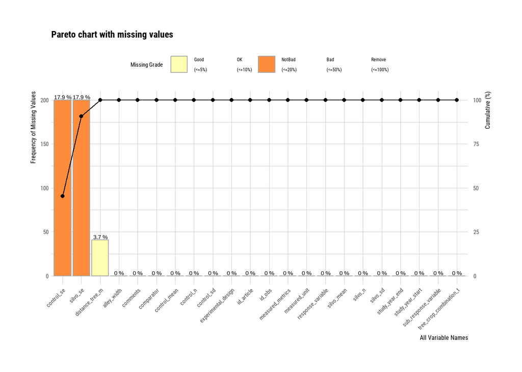

```r
# Visualize pareto chart for variables with missing value.

plot_na_pareto(database_clean)
```

```r
# Indicating a high proportion of NA values in the control_se and silvo_se variables.
# Might need imputation in order to include them in the meta-analysis
```

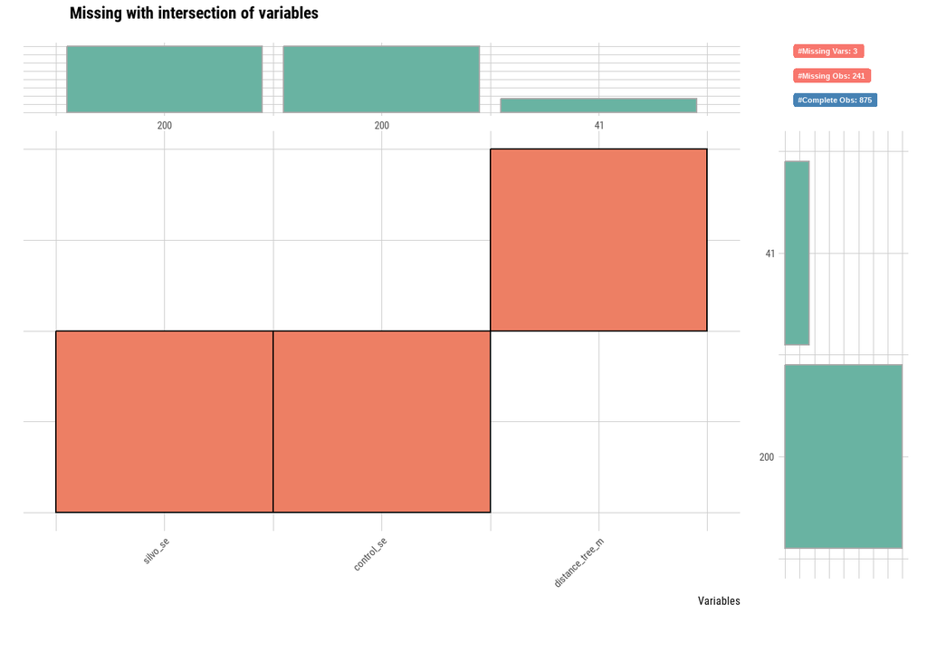

```r
# Visualize the combinations of missing value across cases.

plot_na_intersect(database_clean)
```

```r
eda_report_meta_analysis_SAF <- database_clean |>
  eda_paged_report(#target = "response_variable",
                   subtitle = "Temperate SAF EDA for meta-analysis",
                   output_format = "html",
                   output_file = "EDA_SAF.html")

# Remember to open in Microsoft Edge browser. For some reason Google Chrome is not working
eda_report_meta_analysis_SAF
```

# STEP 3

CALCULATING EFFECT SIZE MEASURE, CHOOSING RESPONSE VARIABLES, AND PERFORM SENSITIVITY ANALYSIS ON MISSING OUTCOME DATA ##########################################################################################################################################